# What makes people happy?

A brief overview of a few determinants of life satisfaction

Philip Unger & Philipp Staender

*This website presents a variety of socio-economic determinants of life-satisfaction. The illustrated graphics are part of the research project: “Can we have it all?”*

Life-satisfaction is a fascinating field of study. On this website we show some interesting correlations between self-reported life-satisfaction and socio-economic characteristics such as gender, income or marriage. If you find this information interesting please also take a look on our study “Can we have it all?”, in which we explore the reconcilability of work and family and its effect on life satisfaction for adults in the United States.

You can find our full research paper [here](https://github.com/philipp-stdr/Final_Project_P-P/blob/master/Final_Project_P-P.pdf).

Note that the figures presented on this website differ from similar figures presented in the research paper, as we do not apply sample restrictions for graphs shown here.

## Determinants of happiness

**How is happiness measured?**

Between 1972-2014, the General Social Survey has asked about 60.000 US adults: *“Taken all together, how would you say things are these days?”* and *“Taking things all together, how would you describe your marriage?”*. Possible answers were “very happy”, “pretty happy” and “not to happy”.

Furthermore, survey respondends were asked *“On the whole, how satisfied are you with the work you do?”* Possible answers range from “very satisfied” to “very dissatisfied”?

Higher numbers indicate higher happiness for all three measures.

[figure not shown]

**Happiness, gender and age**

The graph below shows that women (red line) are on average more likely to be very happy than men (blue line). The difference is largest for young and old people. Around the age of 40 women and men are equally happy.

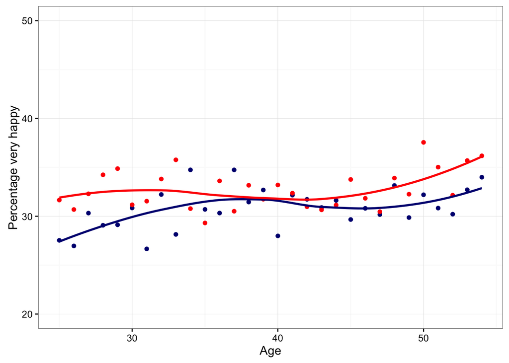

**Income and happiness**

The more you earn the happier you are. This relationship seems to be equally strong for men (blue line) and women (red line) at higher income levels. For incomes below 50.000 USD per year, happiness increases quickly with income for men who earn more than 25.000 USD per year. Women on the other hand first see a slight decline in happiness and no strengthened impact on happiness. As we outline in our research paper, this is because women who stay at home often report rather high levels of happiness.

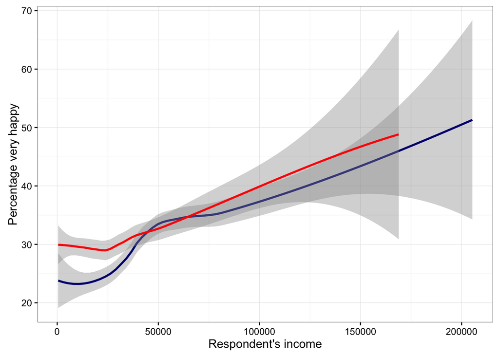

**Work and household constallation**

Does it matter whether you work full-time, part-time or stay at home to take care of house and family? The figure shows that men (blue dots) are much happier when they work full-time compared to part-time employment or staying at home. This does not hold for women (red dots) who seem to be almost equally happy in all three arrangements.

[interactive chart not shown]

**Happiness and marriage/income constellation (college-educated people)**

What is more important, having a high income or being married? In this figure we show the four possible constallations of having a high income[^1] and being married. On average, both college educated men and women are more likely to report being very happy when they are married relative to not being married. Furthermore, when not married, both genders report higher happiness when having a high-income job. For married respondents, however, there are considerable gender differences. When married, men continue to report higher happiness when having high-income, whereas the opposite is true for women. This provides preliminary evidence on the thesis that women face difficulties in reconciling having a high-income job and marriage.

[interactive chart not shown]

Especially the last two figures uncovers some interesting differences between men and women. In our research project we explore several factors that could explain why women find it more difficult to reconcile having a family with a high-income job.

## Further information

Our research project is fully replicatable. All data has been accessed from publicly available sources. You can repiclate the analysis yourself by following the instructions in our [online repository](https://github.com/philipp-stdr/Final_Project_P-P).

If you have any questions please contact us via p.staender@mpp.hertie-school.org or c.unger@mpp.hertie-school.org.

[^1]: Having a high income means that the respondent earns more than the median male respondent from the same age cohort and with the same level of education.